# New sources for evaluating remote-friendly jobs

## Introduction

The COVID-19 pandemic has elevated remote work from a job perk to an important measure to increase social distancing. The crisis has forced us to learn more about what possibilities for working remotely already exists, including questions about what percentage of the workforce are able to work from home, and what types of jobs can be done from home. Some surveys have illuminated aspects of remote opportunities, but more questions remain.

In an alternative approach focusing on existing occupation classifications, we estimate the share of the norwegian workforce able to work remotely by combining register-based labor statistics, annotated job advertisements, and the official documentation of the ISCO-08 standard which is used both in labor statistics and in the job ads. Most of the data about the norwegian workforce is based on register data, and the information we have about what people do at work are based on occupational codes following the ISCO standard. Labor statistics are currently published following the ISCO-08 standard (ILO 2016).

ISCO-08 is a taxonomy aimed at classifying jobs into “occupations”, which are relatable to the reader. These occupations do not say directly wether the job can be performed from home. By evaluating the ISCO-08 documentation, we are able to categorize each occupation as likely or unlikely to be remote-friendly. This classification is evaluated against job ads published by the norwegian welfare administration (NAV) between january 2012 and march 2019, in which there are mentions of remote possibilities.

The fact that a job can be performed remotely does not mean that the employer allows for it, neither does it mean that the employer advertises the possibility. The two measures evaluated here are inherently different, and comparisons between them relies on an assumption that there are not systematic differences in employer remote policies/advertisement across occupations that otherwise could be done from home.

We compare our findings with those published in (Nergaard 2018), which are based on the norwegian labor force survey in 2018 where respondents were asked wether their employer allowed occasional remote work. Yet again this is a different question than the one answered by our own sources.

## Methodology

In order annotate the ISCO-08 documentation and provide a assertion of wether each occupation is likely able to be performed from home, we created a public labeling job through Amazon Mechanical Turk (AWS, n.d.). Each occupation was presented together with a brief description, and the respondent was asked to evaluate wether it was likely that the job could be performed from a private home.

The exact question formulation was “Can this type of job likely be performed from a home office?”, and an example of a job description could be:

> Social work and counselling professionals provide advice and guidance to individuals, families, groups, communities and organizations in response to social and personal difficulties. They assist clients to develop skills and access resources and support services needed to respond to issues arising from unemployment, poverty, disability, addiction, criminal and delinquent behaviour, marital and other problems.

The alternatives were “Yes”, “No” and “Unknown”, which were provided with the following description: - Yes: This job can be performed primarily from an office in a private home - No: Substatantial parts of this job must be performed outside the employees home - Unknown: There is not enough information to decide

The last option, “Unknown” was added in order to reduce arbitrary responses to uninformative occupation descriptions.

Since the job was on Mechanical Turk, there respondents are not subject matter experts, and likely reside in different countries. In order to address potential spurious results, we obtained annotations from five different annotators per occupation. The number of annotators does not correct for possible cultural differences - it is possible that some jobs that cannot be performed remotely in other countries can be performed remotely in Norway. We should therefore consider the annotations as “international”, which is also true for the ISCO-08 standard itself.

The annotations are evaluated against a second novel data source - job ads from the norwegian welfare administration. Since the possibility to work from home is a perk for many, some employers mention it in their job ads in order to attract candidates. We search the texts for mentions of “hjemmekontor” and “heimekontor”, two distinctive words unlikely to mean anything other than the possibility of working from home. Since far from every employer advertise this possibility, it is difficult to say anything about the total number of remote-friendly jobs from these ads. It does however say something important about the relative frequency of remote-friendly jobs across occupational groups, which we can compare to results from Mechanical Turk annotations and from surveys.

## Results

### Total remote-percentage

From the Mechanical Turk annotations we see that 28 per cent of the occupations can likely be performed from home. Taken together with the labor statistics per occupation, we find that 875 344 jobs, 36 per cent of the workforce, are likely able to work from home. This estimate is remarkably similar to a recent NBER working paper (Jonathan I. Dingel 2020), which also inspired this paper.

### Validating results against job-ads

The job ads can not be compared directly to the annotated ISCO-08 data, but one of the comparisons we are able to do is the relative frequency of remote possibilities across occupations. Some job ads mention remote work, and we expect that remote possibilities are mentioned more often within groups where remote are greater.

We compare this frequency with the number of remote-friendly occupations within each broader group. We also compute the composition of remote-friendly jobs across the occupational groups, giving us a measure that is directly comparable.

| ISCO1 | relative_prob_annotations | relative_prob_ads | pctpts_diff |
| --- | --- | --- | --- |
| Managers | 15 | 20.9 | -6.1 |
| Academics | 41 | 23.9 | 17.0 |
| Technicians and associate professionals | 19 | 19.4 | -0.2 |
| clerical support workers | 16 | 19.8 | -4.1 |
| Service and sales workers | 4 | 7.3 | -3.9 |
| Skilled agricultural, forestry and fishery workers | 0 | 0.0 | 0.0 |
| Craft and related trades workers | 6 | 8.0 | -1.9 |
| Plant and machine operators and assemblers | 0 | 0.8 | -0.8 |
| Elementary Occupations | 0 | 0.0 | 0.0 |

The differences here are generally minor considering the disparate data sources, but for academic occupations the difference between the annotations and the ads data requires comment. There are multiple possible interpretations. One is that annotators have been too optimistic in their assertion that the job can be done from home. Another is that the possibility of working from home is taken for granted in many of these occupations, and advertising it is therefore superfluous. Yet another possibility is that these occupations are indeed very remote friendly, but employers are conservative in letting employees bring their job home. In the first case, covid-19 won’t see the level of remote adoption that are indicated by the annotations, but in either of the latter cases, employers may find themselves sending their employees home in troves.

The correlation between the two measures are strong, but in order to evaluate it statistically we would benefit from more detailed data. One approach is to use a logistic regression explaining the annotation of an occupation (a binary label) with the ratio of mentions of “hjemmekontor” in the ad.

| term | estimate | std.error | statistic | p.value |
| --- | --- | --- | --- | --- |
| (Intercept) | -1 | 0.1 | -8 | 0.00 |
| Remote mentions | 31 | 15.9 | 2 | 0.05 |

Menitoning “hjemmekontor” in the add is significantly correlated with the annotation, if only within an inch of the usual 5 % significance threshold. Given the spuriousness of the data sources, the results seem fairly well aligned.

As a pragmatic final check we include the frequency of occupations in the comparison. Like many other high-cardinality categorical variables, we see some very common occupations and a long tail of less frequent ones. When analyzing real data, the most common occupations will have a major effect on the results, while the more esoteric ones are less likely to impact the analysis.

| ISCO1 | relative_prob_annotations | relative_prob_ads | diff |
| --- | --- | --- | --- |
| 1 | 0.0 | 0.0 | 0.0 |
| 2 | 0.7 | 0.5 | 0.2 |
| 3 | 0.1 | 0.3 | -0.2 |
| 4 | 0.1 | 0.1 | 0.0 |
| 5 | 0.0 | 0.1 | 0.0 |
| 6 | 0.0 | 0.0 | 0.0 |
| 7 | 0.1 | 0.0 | 0.0 |
| 8 | 0.0 | 0.0 | 0.0 |
| 9 | 0.0 | 0.0 | 0.0 |

The weighted comparisons show a similar pattern, Academic occupations still appear to underadvertise or underutilize remote possibilities compared to what the annotations suggests, but the weighted numbers show a large new difference for Technicians and associate professionals. This may suggest that one or more large occupations within this broader group advertise their remote possibilities more than normal, or that the annotations are incorrect.

### Analyzing the remote occupations

We can see what percentage of occupations are remote-friendly across occupational groups:

| ISCO1 | antall | remote_antall | remote_pct |
| --- | --- | --- | --- |
| Managers | 183412 | 94959 | 523 |
| Academics | 576136 | 297256 | 521 |
| Technicians and associate professionals | 373065 | 158504 | 429 |
| clerical support workers | 169230 | 112842 | 674 |
| Service and sales workers | 570761 | 165493 | 293 |
| Skilled agricultural, forestry and fishery workers | 21631 | 0 | 0 |
| Craft and related trades workers | 219658 | 46290 | 213 |
| Plant and machine operators and assemblers | 163197 | 0 | 0 |
| Elementary Occupations | 134400 | 0 | 0 |

This bears resemblance to the table comparing the relative percentages of ads and annotations, but now using absolute numbers. Managers and academics do indeed often have jobs that can be performed from home, but this is even more the case for clerical support workers where two thirds theoretically could be working from home.

The geographic location of jobs have been a point of interest for years, amid both pressure for workers to centralize and specialize, and fears of increased inequality between cities and rural areas. Cities have a higher share of remote-friendly jobs, which may be fortunate given the need for social distancing.

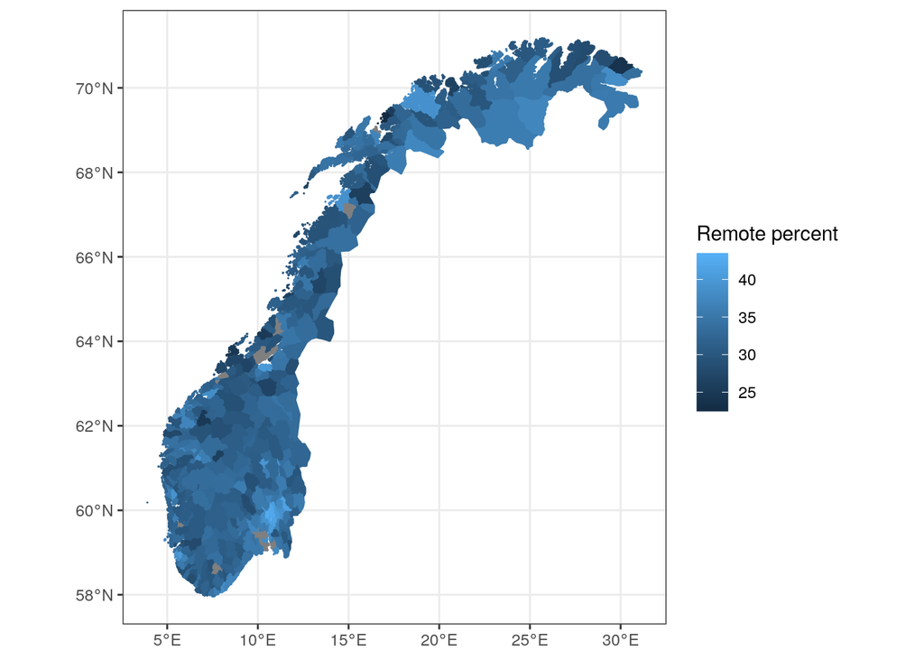

The pattern looks clear, especially in the area surrounding Oslo but also the other cities like Bergen, Trondheim and Stavanger seems to stand out on the map.

By introducing a measure of urbanness, we can analyze the relationship more formally. Using population per square km as a proxy for urbanness, we see a clear correlation between “urbanness”, or population pr km$^2$, and the availability of remote-friendly jobs.

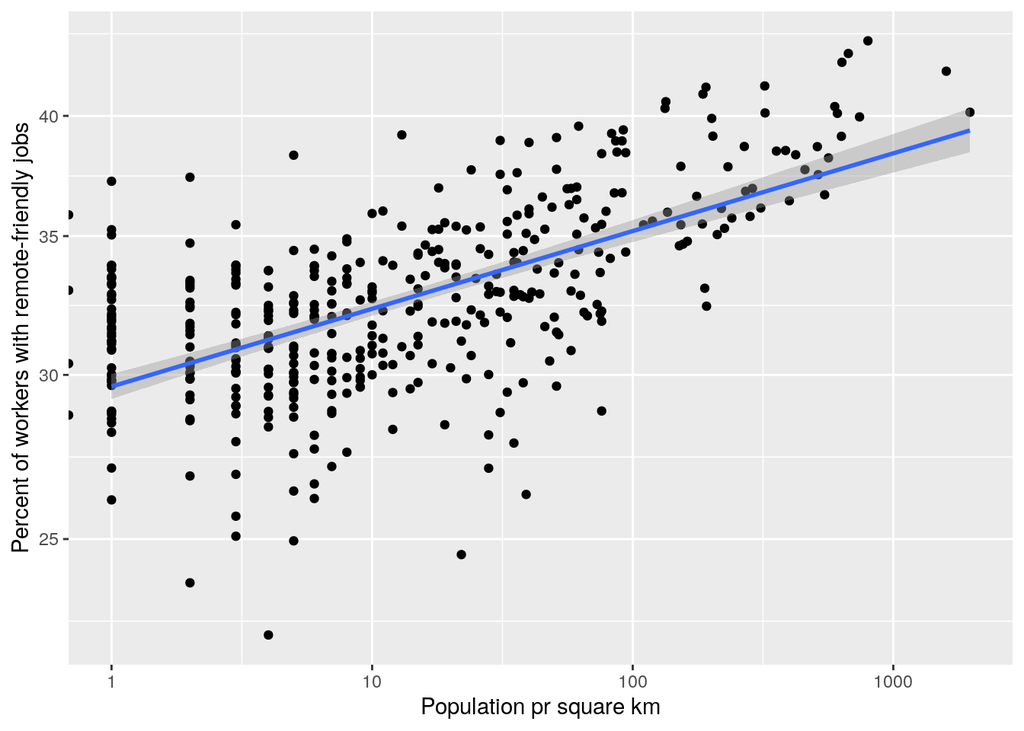

In the simple linear model we have fitted, density, measured as person pr km$^2$, is clearly significant.

| term | estimate | std.error | statistic | p.value |
| --- | --- | --- | --- | --- |
| (Intercept) | 32.08 | 0.1488 | 216 | 0 |
| density | 0.01 | 0.0008 | 13 | 0 |

## Similar work

The norwegian labor force survey has asked about remote-possibilities, covered in a report by FAFO (Nergaard 2018). The question was wether the respondent had the opportunity to work from home at times, which is not to say that the job could be performed remotely in its entirety, and neither to say that those who weren’t given the opportunity couldn’t have worked from home if they had the option.

Nevertheless the results from this survey was broadly similar to these. In the survey, 71 per cent of managers responded that they had opportunity to work from home at times, much higher than the results here. This difference is likely attributable to the distinction mentioned above: Being able to perform *some* part of your job remotely does not mean that the job can be performed *primarily* remotely.

## Further work

The sudden question of remote work highlights the need to expand our knowledge of occupations and their contents. For National Statistical Institutions in Europe, the most natural option would be to expand the existing ESCO ontology with this data. The results we have found also suggest that alternative approaches to collecting such information is feasible.

AWS. n.d. “Amazon Mechanical Turk.” https://www.mturk.com/.

ILO. 2016. “ISCO - International Standard Classification of Occupations.” https://www.ilo.org/public/english/bureau/stat/isco/isco08/index.htm.

Jonathan I. Dingel, Brent Neiman. 2020. “How Many Jobs Can Be Done at Home?” https://www.nber.org/papers/w26948.pdf.

Nergaard. 2018. “Fleksibel Arbeidstid: En Analyse Av Ordninger I Norsk Arbeidsliv.” https://www.fafo.no/images/pub/2018/20664.pdf.